# Exam 1

Elizabeth Stoner

10/04/2021

# Instructions

1. Create a folder in your computer (a good place would be under Crim 250, Exams).
2. Download the dataset from the Canvas website (fatal-police-shootings-data.csv) onto that folder, and save your Exam 1.Rmd file in the same folder.
3. Download the README.md file. This is the codebook.
4. Load the data into an R data frame.

```r
library(readr)
fatal_police_shootings_data <- dat<-read_csv("fatal-police-shootings-data.csv")
View(dat)
```

# Problem 1 (10 points)

1. Describe the dataset. This is the source: https://github.com/washingtonpost/data-police-shootings . Write two sentences (max.) about this.

**The dataset describes information about fatal police shootings in the US from 2015 to 2021. There are 6594 subjects included in teh dataset.**

2. How many observations are there in the data frame?

```r
names(dat) #Lists the names of all the variables in dat
```

```
##  [1] "id"                      "name"
##  [3] "date"                    "manner_of_death"
##  [5] "armed"                   "age"
##  [7] "gender"                  "race"
##  [9] "city"                    "state"
## [11] "signs_of_mental_illness" "threat_level"
## [13] "flee"                    "body_camera"
## [15] "longitude"               "latitude"
## [17] "is_geocoding_exact"
```

**There are 17 categories used to observe 6594 individuals, so 6594 observations.**

3. Look at the names of the variables in the data frame. Describe what “body_camera”, “flee”, and “armed” represent, according to the codebook. Again, only write one sentence (max) per variable.

**“Body camera” means whether news reports indicated that the officer was wearing a body camera at the time of the incident, which may have recorded some of the events. “Flee” means whether news reports said that the subject was moving away from the officer. “Armed” indicates whether the subject was armed with some sort of object that the officer believed could have caused harm.**

4. What are three weapons that you are surprised to find in the “armed” variable? Make a table of the values in “armed” to see the options.

```r
table(dat$armed)
```

```
##
##                  air conditioner                       air pistol
##                                1                                1
##                   Airsoft pistol                               ax
##                                3                               24
##                         barstool                     baseball bat
##                                1                               20
##          baseball bat and bottle baseball bat and fireplace poker
##                                1                                1
##           baseball bat and knife                            baton
##                                1                                6
##                           BB gun               BB gun and vehicle
##                               15                                1
##                     bean-bag gun                      beer bottle
##                                1                                3
##                       binoculars                     blunt object
##                                1                                5
##                           bottle                    bow and arrow
##                                1                                1
##                       box cutter                            brick
##                               13                                2
##              car, knife and mace                          carjack
##                                1                                1
##                            chain                        chain saw
##                                3                                2
##                         chainsaw                            chair
##                                1                                4
##              claimed to be armed               contractor's level
##                                1                                1
##                   cordless drill                         crossbow
##                                1                                9
##                          crowbar                        fireworks
##                                5                                1
##                         flagpole                       flashlight
##                                1                                2
##                      garden tool                      glass shard
##                                2                                4
##                          grenade                              gun
##                                1                             3798
##                      gun and car                    gun and knife
```

[output cut: 44 more lines]

```
##                                2                                1
##              straight edge razor                            sword
##                                5                               23
##                            Taser                        tire iron
##                               34                                4
##                       toy weapon                          unarmed
##                              226                              421
##                     undetermined                   unknown weapon
##                              188                               82
##                          vehicle                  vehicle and gun
##                              213                                8
##              vehicle and machete                    walking stick
##                                1                                1
##                       wasp spray                           wrench
##                                1                                1
```

**I find it most surprising to see an air conditioner, wasp spray, and a microphone in the “armed” variable.**

# Problem 2 (10 points)

1. Describe the age distribution of the sample. Is this what you would expect to see?

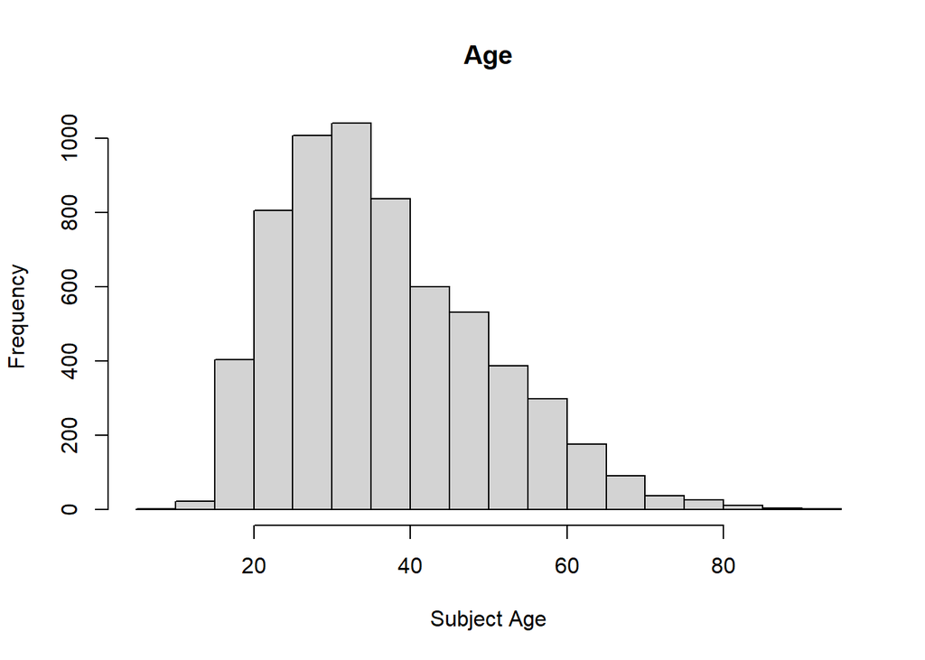

```r
hist(dat$age, main="Age", xlab="Subject Age", ylab="Frequency")
```

**There seems to be a higher frequency of ages 20 to 40, so the plot has a right skew. It makes sense that people from these age ranges may be more likely to be involved in police incidents. They are able to be more active, unlike many in their eighties. There is a rather steady decline starting from age 40 going to 80 in the ages of those involved in fatal police shootings. This is also what I would expect. The older people get, the less likely they are to engage in criminal activities, or activities that could be mistaken for criminal activities. Older people may also seem less threatening, so officers may be less inclined to use deadly force on them.**

2. To understand the center of the age distribution, would you use a mean or a median, and why? Find the one you picked.

```r
summary(dat$age)
```

```
##    Min. 1st Qu.  Median    Mean 3rd Qu.    Max.    NA's
##    6.00   27.00   35.00   37.12   45.00   91.00     308
```

**To find the center of a distribution it is best to use the median, which is the middle value of a dataset. For this age distribution the median is 35.**

3. Describe the gender distribution of the sample. Do you find this surprising?

```r
table(dat$gender)
```

```
##
##    F    M
##  293 6298
```

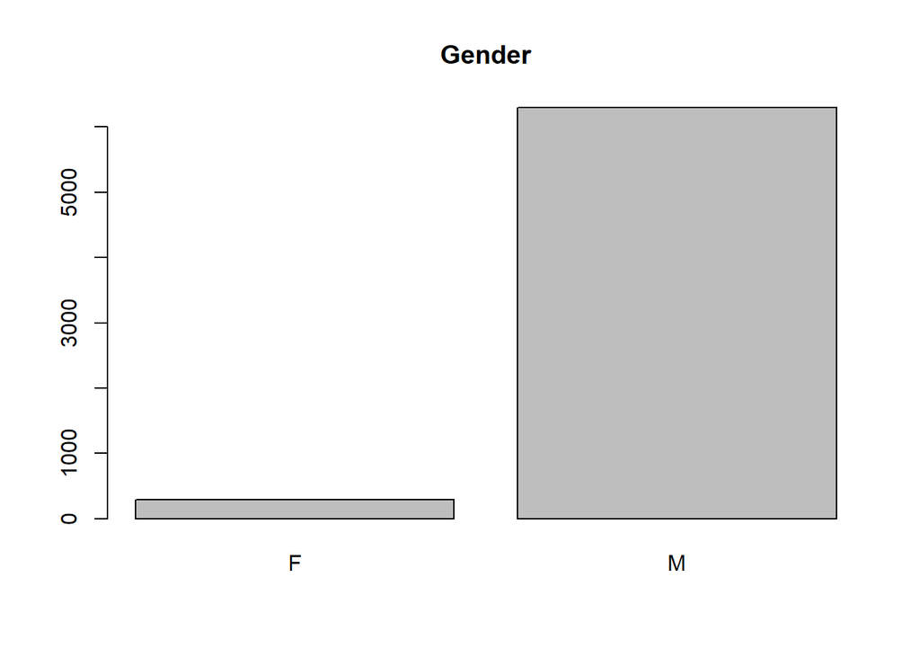

```r
barplot(table(dat$gender), main="Gender") #Organizing the data into a barplot to visualize the distribution
```

**There are 6298 males and 293 females in the dataset. While I would expect there to be more males than females, I am very surprised that there are over twenty times more males than females involved in fatal police shootings.**

# Problem 3 (10 points)

1. How many police officers had a body camera, according to news reports? What proportion is this of all the incidents in the data? Are you surprised that it is so high or low?

```r
table(dat$body_camera)
```

```
##
## FALSE  TRUE
##  5684   910
```

**According to news reports only 910 officers had a body camera to capture parts of the incidents. This is less than one sixth of all of the incidents in the data. I am quite surprised at how low it is. I would also expect that in recent years there would be a greater increase in body camera use; however, looking at the dataset that does not seem to be the case.**

2. In how many of the incidents was the victim fleeing? What proportion is this of the total number of incidents in the data? Is this what you would expect?

```r
table(dat$flee)
```

```
##
##         Car        Foot Not fleeing       Other
##        1058         845        3952         248
```

# Problem 4 (10 points) - Answer only one of these (a or b).

1. Describe the relationship between the variables “body camera” and “flee” using a stacked barplot. What can you conclude from this relationship?

*Hint 1: The categories along the x-axis are the options for “flee”, each bar contains information about whether the police officer had a body camera (vertically), and the height along the y-axis shows the frequency of that category).*

*Hint 2: Also, if you are unsure about the syntax for barplot, run ?barplot in R and see some examples at the bottom of the documentation. This is usually a good way to look up the syntax of R code. You can also Google it.*

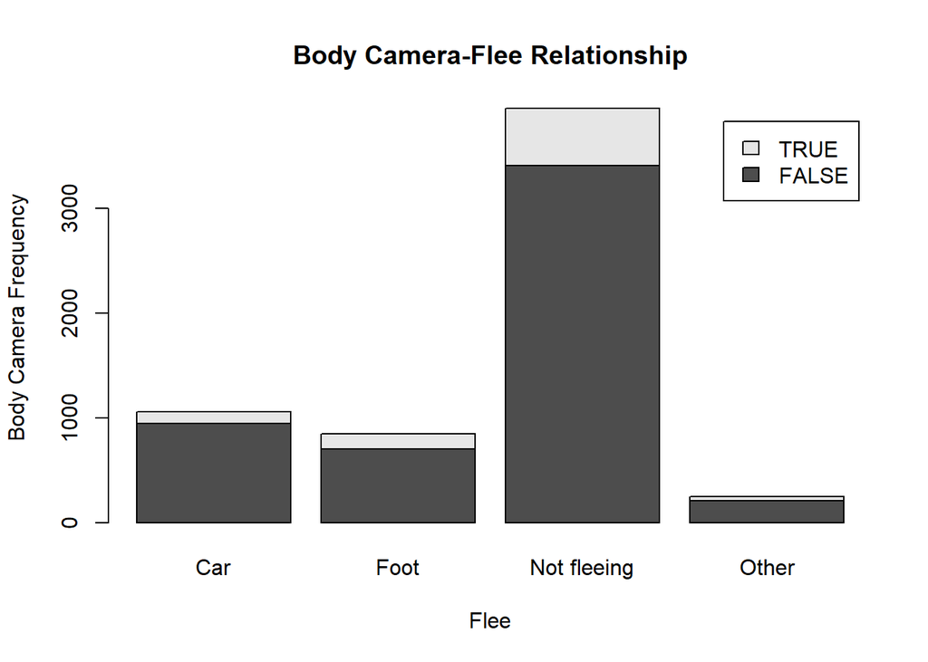

```r
tab.bodycameraflee<-table(dat$body_camera, dat$flee) #Making a table for both variables
barplot(tab.bodycameraflee, main="Body Camera-Flee Relationship", xlab="Flee", ylab="Body Camera Frequency", legend.text=rownames(tab.bodycameraflee),
        beside = FALSE) #Stacked barplot code using the tables
```

**From looking at the barplot it is clear that in the majority of cases the officers were not reported to have body cameras. For the cases in which the victims fled, very few officers were reported to have body cameras. The officers were reported to have body cameras mostly when the victims were not fleeing. As this is the largest category, it makes sense that it would also happen to have the most instances of officers having body cameras. This barplot might suggest that when the victims fled, officers perhaps turned off or removed their body cameras. Or the footage could be obstructed due to the action. It makes sense that it is easiest to capture footage of a victim who is stationary. However, the data does not explain the staggering lack of body camera use in all of the categories. Even in the not fleeing category very few officers were reported to have body cameras. It should also be noted that the Other category is likely missing data about whether the victim fled or not.**

2. Describe the relationship between age and race by using a boxplot. What can you conclude from this relationship?

*Hint 1: The categories along the x-axis are the race categories and the height along the y-axis is age.*

*Hint 2: Also, if you are unsure about the syntax for boxplot, run ?boxplot in R and see some examples at the bottom of the documentation. This is usually a good way to look up the syntax of R code. You can also Google it.*

# Extra credit (10 points)

1. What does this code tell us?

```r
mydates <- as.Date(dat$date) #renames the date category as "mydates"
head(mydates) #finds the first part of the vector mydates
(mydates[length(mydates)] - mydates[1]) #sets the length of the vector list for mydates
```

[output not shown]

**This code tells us about the values in the vector list renamed to “mydates”.**